# 基于智能体驱动的下一代测试平台 AgentRunner

- **生成时间**: 2026-03-08 15:15:28
- **数据源**: F:-template.json
- **操作总数**: 20

# 1. 第一步：mouse

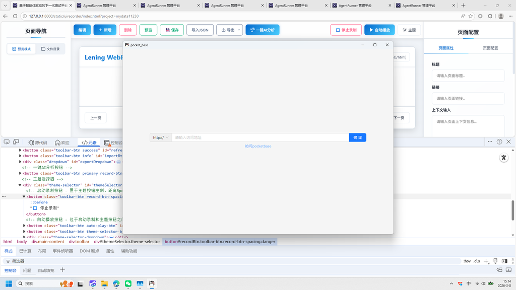

操作截图

**操作详情**: + 操作类型: mouse; + 时间戳: 2026-03-08T15:14:09.692475; + 位置: (562, 1066); + 按钮: Button.left; + 时间戳: 2026-03-08T15:14:09.217193

# 2. 第二步：mouse

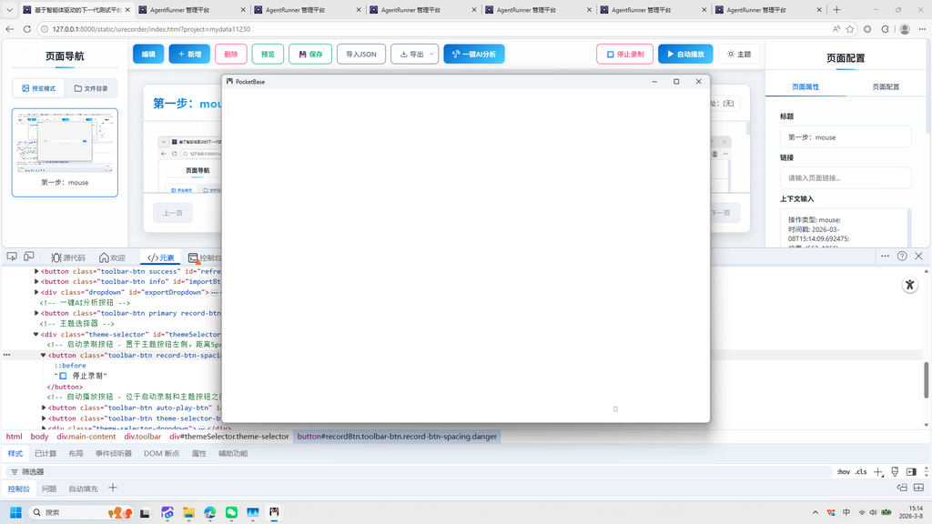

操作截图

**操作详情**: + 操作类型: mouse; + 时间戳: 2026-03-08T15:14:10.885043; + 位置: (987, 545); + 按钮: Button.left; + 时间戳: 2026-03-08T15:14:10.401451

# 3. PocketBase管理后台登录界面

[figure not shown]

操作截图

**操作详情**: + 操作类型: mouse; + 时间戳: 2026-03-08T15:14:13.353166; + 位置: (913, 451); + 按钮: Button.left; + 时间戳: 2026-03-08T15:14:12.889248

**页面描述**: 该图像展示了一个名为PocketBase的管理平台的登录界面。界面中央为登录表单，包含邮箱和密码输入框，以及一个登录按钮。页面顶部显示了PocketBase的品牌标识，底部有版本信息。整体设计简洁现代，专注于管理员身份验证流程。

# 4. 第四步：keyboard

[figure not shown]

操作截图

**操作详情**: + 操作类型: keyboard; + 时间戳: 2026-03-08T15:14:20.786151; + 输入内容: ding465398889@163.com; + 长度: 21; + 首字符: d; + 末字符: m; + 结束原因: tab_key; + 时间戳: 2026-03-08T15:14:20.505245; + 截图类型: 首字符

# 5. 第五步：keyboard

[figure not shown]

操作截图

**操作详情**: + 操作类型: keyboard; + 时间戳: 2026-03-08T15:14:20.789209; + 输入内容: ding465398889@163.com; + 长度: 21; + 首字符: d; + 末字符: m; + 结束原因: tab_key; + 时间戳: 2026-03-08T15:14:20.505245; + 截图类型: 末字符

# 6. 第六步：mouse

[figure not shown]

操作截图

**操作详情**: + 操作类型: mouse; + 时间戳: 2026-03-08T15:14:28.907845; + 位置: (854, 556); + 按钮: Button.left; + 时间戳: 2026-03-08T15:14:28.433852

# 7. 第七步：mouse

[figure not shown]

操作截图

**操作详情**: + 操作类型: mouse; + 时间戳: 2026-03-08T15:14:32.663031; + 位置: (962, 670); + 按钮: Button.left; + 时间戳: 2026-03-08T15:14:32.225544

# 8. 第八步：mouse

[figure not shown]

操作截图

**操作详情**: + 操作类型: mouse; + 时间戳: 2026-03-08T15:14:34.520068; + 位置: (492, 351); + 按钮: Button.left; + 时间戳: 2026-03-08T15:14:34.056612

# 9. 第九步：mouse

[figure not shown]

操作截图

**操作详情**: + 操作类型: mouse; + 时间戳: 2026-03-08T15:14:35.025088; + 位置: (494, 431); + 按钮: Button.left; + 时间戳: 2026-03-08T15:14:34.521067

# 10. 第十步：keyboard

[figure not shown]

操作截图

**操作详情**: + 操作类型: keyboard; + 时间戳: 2026-03-08T15:14:35.169195; + 输入内容: 1234567899 + 1234567890; + 长度: 21; + 首字符: 1; + 末字符: 0; + 结束原因: timeout; + 时间戳: 2026-03-08T15:14:34.834568; + 截图类型: 首字符

# 11. 第十一步：keyboard

[figure not shown]

操作截图

**操作详情**: + 操作类型: keyboard; + 时间戳: 2026-03-08T15:14:35.173192; + 输入内容: 1234567899 + 1234567890; + 长度: 21; + 首字符: 1; + 末字符: 0; + 结束原因: timeout; + 时间戳: 2026-03-08T15:14:34.834568; + 截图类型: 末字符

# 12. 第十二步：mouse

[figure not shown]

操作截图

**操作详情**: + 操作类型: mouse; + 时间戳: 2026-03-08T15:14:36.070763; + 位置: (616, 366); + 按钮: Button.left; + 时间戳: 2026-03-08T15:14:35.593374

# 13. 第十三步：mouse

[figure not shown]

操作截图

**操作详情**: + 操作类型: mouse; + 时间戳: 2026-03-08T15:14:36.548890; + 位置: (610, 429); + 按钮: Button.left; + 时间戳: 2026-03-08T15:14:35.970985

# 14. 第十四步：mouse

[figure not shown]

操作截图

**操作详情**: + 操作类型: mouse; + 时间戳: 2026-03-08T15:14:37.011735; + 位置: (613, 408); + 按钮: Button.left; + 时间戳: 2026-03-08T15:14:36.431168

# 15. 第十五步：mouse

[figure not shown]

操作截图

**操作详情**: + 操作类型: mouse; + 时间戳: 2026-03-08T15:14:37.507646; + 位置: (646, 495); + 按钮: Button.left; + 时间戳: 2026-03-08T15:14:36.918003

# 16. 第十六步：mouse

[figure not shown]

操作截图

**操作详情**: + 操作类型: mouse; + 时间戳: 2026-03-08T15:14:38.221757; + 位置: (629, 655); + 按钮: Button.left; + 时间戳: 2026-03-08T15:14:37.762618

# 17. 第十七步：mouse

[figure not shown]

操作截图

**操作详情**: + 操作类型: mouse; + 时间戳: 2026-03-08T15:14:38.695625; + 位置: (633, 711); + 按钮: Button.left; + 时间戳: 2026-03-08T15:14:38.192702

# 18. 第十八步：mouse

[figure not shown]

操作截图

**操作详情**: + 操作类型: mouse; + 时间戳: 2026-03-08T15:14:39.173273; + 位置: (611, 758); + 按钮: Button.left; + 时间戳: 2026-03-08T15:14:38.600938

# 19. 第十九步：mouse

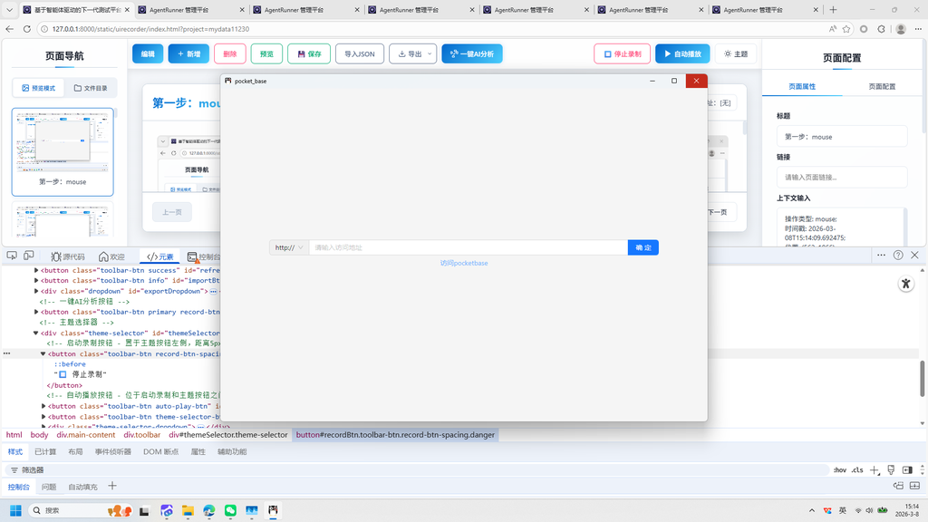

操作截图

**操作详情**: + 操作类型: mouse; + 时间戳: 2026-03-08T15:14:40.788985; + 位置: (1425, 174); + 按钮: Button.left; + 时间戳: 2026-03-08T15:14:40.281110

# 20. 第二十步：mouse

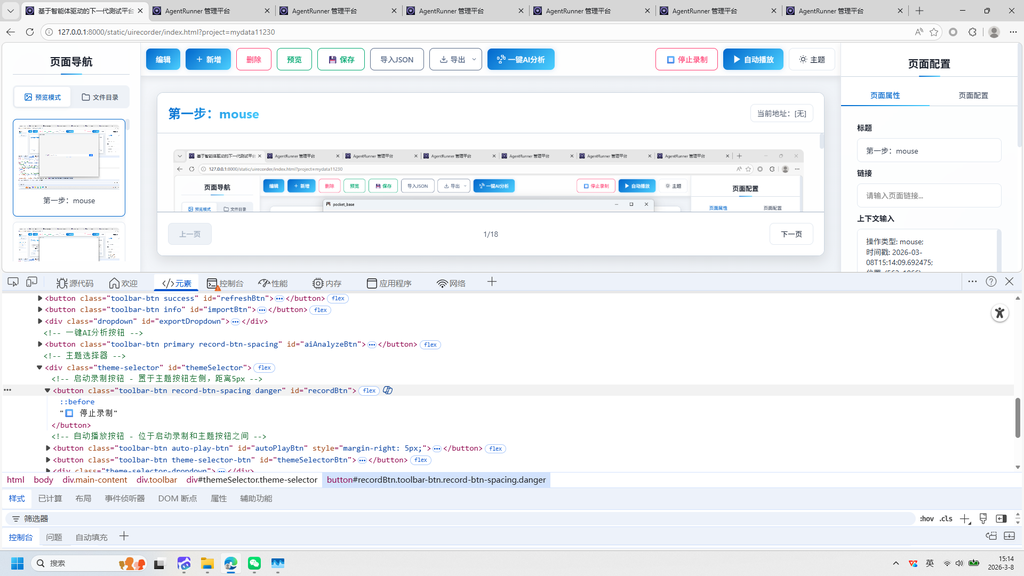

操作截图

**操作详情**: + 操作类型: mouse; + 时间戳: 2026-03-08T15:14:41.383364; + 位置: (1423, 171); + 按钮: Button.left; + 时间戳: 2026-03-08T15:14:40.867566

*报告由 AgentRunner Markdown Exporter 生成*